# Deer Exclosure Data Analysis (2025)

## Ocular Cover Estimates

**The raw cover estimates for the three treatments are as follows.**

```
## [1] "Control"
```

| Location | Woody_% | Grasses_% | Forbs_% | NVGround_% | Other_% |
| --- | --- | --- | --- | --- | --- |
| East Inside | 0.308 | 0.010 | 0.078 | 0.625 | 0.042 |
| West Inside | 0.078 | 0.072 | 0.122 | 0.667 | 0.015 |
| East Outside | 0.137 | 0.022 | 0.055 | 0.782 | 0.010 |
| West Outside | 0.112 | 0.002 | 0.065 | 0.725 | 0.000 |
| Inside Total | 0.192 | 0.041 | 0.100 | 0.646 | 0.029 |
| Outside Total | 0.125 | 0.013 | 0.060 | 0.754 | 0.005 |

```
## [1] "Two-Sided Treatment"
```

| Location | Woody_% | Grasses_% | Forbs_% | NVGround_% | Other_% |
| --- | --- | --- | --- | --- | --- |
| East Inside | 0.298 | 0.057 | 0.220 | 0.382 | 0 |
| West Inside | 0.380 | 0.015 | 0.208 | 0.478 | 0 |
| East Outside | 0.266 | 0.006 | 0.116 | 0.591 | 0 |
| West Outside | 0.278 | 0.070 | 0.158 | 0.527 | 0 |
| Inside Total | 0.339 | 0.036 | 0.214 | 0.430 | 0 |
| Outside Total | 0.272 | 0.042 | 0.139 | 0.556 | 0 |

```
## [1] "Four-Sided Treatment"
```

| Location | Woody_% | Grasses_% | Forbs_% | NVGround_% | Other_% |
| --- | --- | --- | --- | --- | --- |
| East Inside | 0.310 | 0.360 | 0.170 | 0.265 | 0.000 |
| West Inside | 0.428 | 0.182 | 0.032 | 0.348 | 0.000 |
| East Outside | 0.215 | 0.288 | 0.098 | 0.415 | 0.015 |
| West Outside | 0.195 | 0.282 | 0.085 | 0.430 | 0.000 |
| Inside Total | 0.369 | 0.271 | 0.101 | 0.306 | 0.000 |
| Outside Total | 0.205 | 0.285 | 0.091 | 0.422 | 0.007 |

**The cover estimates were adjusted to 1 (or 100%) before rounding. The results are as follows.**

```
## [1] "Control"
```

| Location | Woody_% | Grasses_% | Forbs_% | NVGround_% | Other_% |
| --- | --- | --- | --- | --- | --- |
| East Inside | 0.287 | 0.010 | 0.073 | 0.594 | 0.037 |
| West Inside | 0.079 | 0.076 | 0.121 | 0.708 | 0.016 |
| East Outside | 0.140 | 0.019 | 0.048 | 0.783 | 0.009 |
| West Outside | 0.125 | 0.003 | 0.078 | 0.794 | 0.000 |
| Inside Total | 0.183 | 0.043 | 0.097 | 0.651 | 0.026 |
| Outside Total | 0.133 | 0.011 | 0.063 | 0.789 | 0.005 |

```
## [1] "Two-Sided Treatment"
```

| Location | Woody_% | Grasses_% | Forbs_% | NVGround_% | Other_% |
| --- | --- | --- | --- | --- | --- |
| East Inside | 0.317 | 0.060 | 0.233 | 0.389 | 0 |
| West Inside | 0.359 | 0.014 | 0.201 | 0.427 | 0 |
| East Outside | 0.280 | 0.006 | 0.118 | 0.595 | 0 |
| West Outside | 0.270 | 0.060 | 0.141 | 0.528 | 0 |
| Inside Total | 0.338 | 0.037 | 0.217 | 0.408 | 0 |
| Outside Total | 0.275 | 0.036 | 0.131 | 0.558 | 0 |

```
## [1] "Four-Sided Treatment"
```

| Location | Woody_% | Grasses_% | Forbs_% | NVGround_% | Other_% |
| --- | --- | --- | --- | --- | --- |
| East Inside | 0.273 | 0.344 | 0.154 | 0.229 | 0.000 |
| West Inside | 0.451 | 0.186 | 0.033 | 0.330 | 0.000 |
| East Outside | 0.214 | 0.263 | 0.099 | 0.407 | 0.018 |
| West Outside | 0.221 | 0.280 | 0.084 | 0.415 | 0.000 |
| Inside Total | 0.362 | 0.265 | 0.093 | 0.280 | 0.000 |
| Outside Total | 0.218 | 0.271 | 0.092 | 0.411 | 0.009 |

**The average ocular cover was plotted for each treatment group. The averages are of the raw, not the adjusted, data.**

**The plot below compares inside and outside transects between the Control and the Four-Sided treatment groups.**

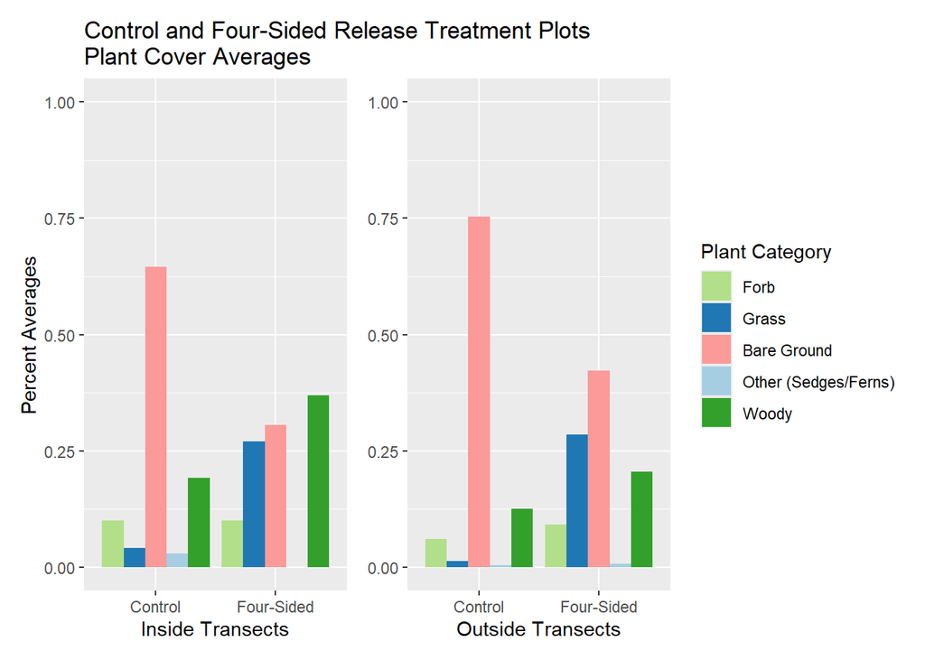

**Below are the plots comparing the inside and outside transects between all three treatment groups.**

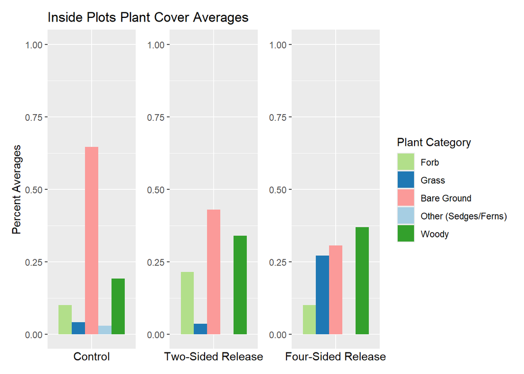

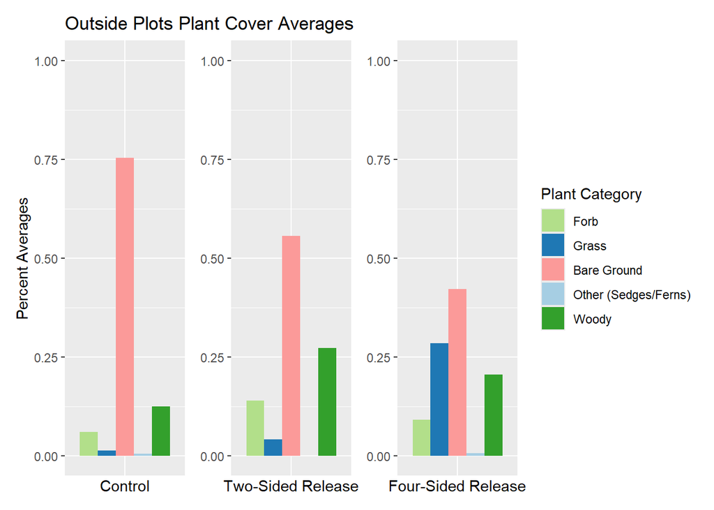

## Species Richness

**Species richness for each vegetation category is plotted for each treatment group below.**

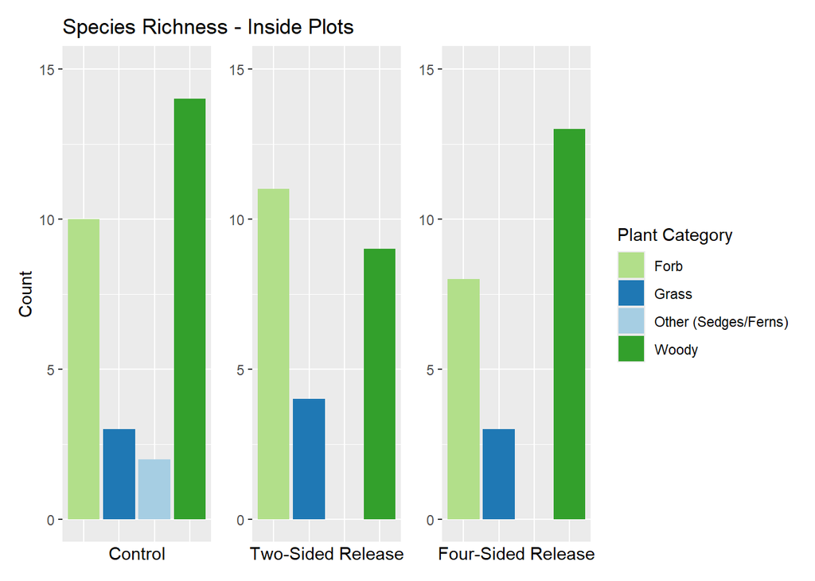

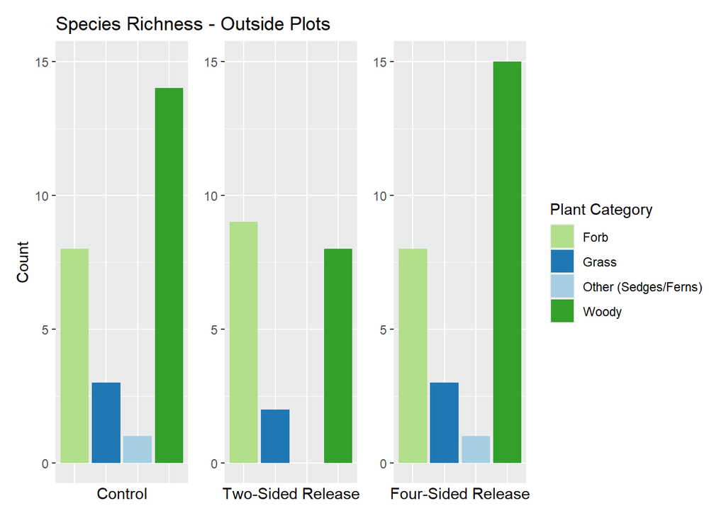

## Proportion Invasive Species

**The proportion of invasive species by vegetation key (or category) inside and outside the Control treatment is as follows.**

```
## [1] "Inside: Count and Proportion of Invasive Species"
```

```
## # A tibble: 2 × 4
##   Key   Invasive_Count Tot_Count Prop_Invasive
##   <chr>          <int>     <int>         <dbl>
## 1 F                 11        71         0.155
## 2 W                  3       126         0.024
```

```
## [1] "Outside: Count and Proportion of Invasive Species"
```

```
## # A tibble: 2 × 4
##   Key   Invasive_Count Tot_Count Prop_Invasive
##   <chr>          <int>     <int>         <dbl>
## 1 F                  3        46         0.065
## 2 W                 13        84         0.155
```

**The proportion of invasive species by vegetation key (or category) inside and outside the Two=Sided treatment is as follows.**

```
## [1] "Inside: Count and Proportion of Invasive Species"
```

```
## # A tibble: 3 × 4
##   Key   Invasive_Count Tot_Count Prop_Invasive
##   <chr>          <int>     <int>         <dbl>
## 1 F                 15       188         0.08
## 2 G                 27        72         0.375
## 3 W                 12       160         0.075
```

```
## [1] "Outside: Count and Proportion of Invasive Species"
```

```
## # A tibble: 3 × 4
##   Key   Invasive_Count Tot_Count Prop_Invasive
##   <chr>          <int>     <int>         <dbl>
## 1 F                 56       175         0.32
## 2 G                 60        65         0.923
## 3 W                 27       169         0.16
```

**The proportion of invasive species by vegetation key (or category) inside and outside the Four-Sided treatment is as follows.**

```
## [1] "Inside: Count and Proportion of Invasive Species"
```

```
## # A tibble: 2 × 4
##   Key   Invasive_Count Tot_Count Prop_Invasive
##   <chr>          <int>     <int>         <dbl>
## 1 G                581       586         0.991
## 2 W                  5       161         0.031
```

```
## [1] "Outside: Count and Proportion of Invasive Species"
```

```
## # A tibble: 3 × 4
##   Key   Invasive_Count Tot_Count Prop_Invasive
##   <chr>          <int>     <int>         <dbl>
## 1 F                  2       128         0.016
## 2 G                429       459         0.935
## 3 W                 17       136         0.125
```

**The proportions of invasive woody species for all three treatments are plotted below.**

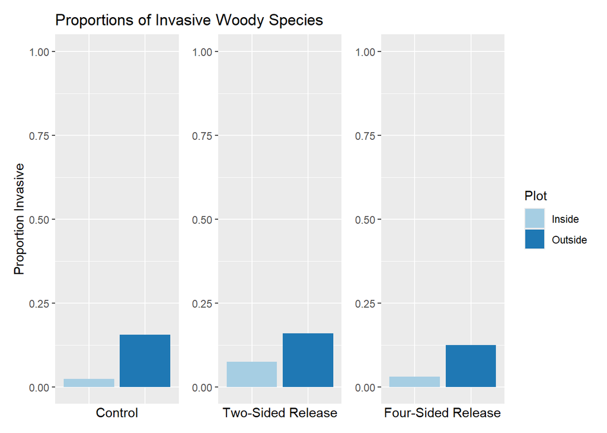

## Browse

**Calculations for percent browse per species and average heights of browsed versus unbrowsed woody species assume that the inside subplots were not browsed. Thus, all browse data uses only the outside subplots in each treatment zone.**

**The percent browse of woody and forb species in the Control:**

```
## [1] "Percent Browse of Woody and Forb Species - Control"
```

| Key | Species | Percent_Browse |
| --- | --- | --- |
| F | EnchantNight | 0.0 |
| F | JewelW | 0.0 |
| F | Persicaria | 0.0 |
| F | Solidago | 22.2 |
| W | Ash | 62.5 |
| W | Cherry | 25.0 |
| W | MfRose | 70.0 |
| W | VACreep | 0.0 |

**The percent browse of woody and forb species in the Two-Sided Release:**

```
## [1] "Percent Browse of Woody and Forb Species - Two-Sided"
```

| Key | Species | Percent_Browse |
| --- | --- | --- |
| F | Galium | 0.0 |
| F | GarlicMus | 0.0 |
| F | JewelW | 32.0 |
| F | Nightshade | 60.0 |
| F | Persicaria | 2.6 |
| F | UnkForb | 44.4 |
| F | WhiteAvens | 16.7 |
| W | Ash | 63.9 |
| W | BlkCherry | 77.8 |
| W | Cherry | 25.0 |

[output cut: 3 more lines]

**The percent browse of woody and forb species in the Four-Sided Release:**

```
## [1] "Percent Browse of Woody and Forb Species - Four-Sided"
```

| Key | Species | Percent_Browse |
| --- | --- | --- |
| F | CinqSpp | 8.3 |
| F | EnchantNight | 5.6 |
| F | JewelW | 58.1 |
| F | Nightshade | 9.1 |
| F | Persicaria | 9.5 |
| F | UnkForb | 0.0 |
| F | Violet | 12.5 |
| W | Ash | 79.5 |
| W | Cherry | 50.0 |
| W | JBarb | 0.0 |

[output cut: 3 more lines]

**The figure below plots woody species in each treatment group by most to least browsed. Only woody species found in the outside subplots were plotted. Each plot has its own Key to increase legibility (otherwise there was text overlap).**

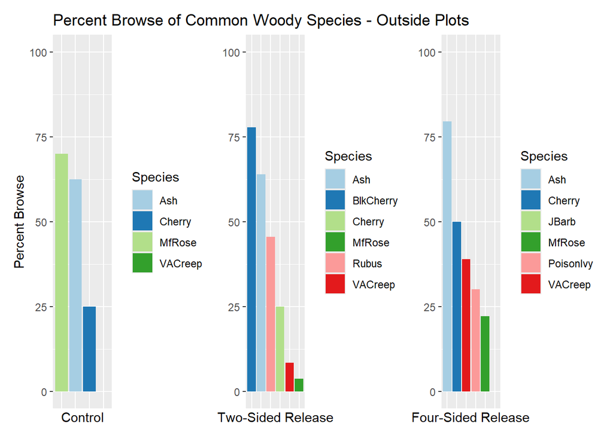

## Average Woody Species Heights

**The average heights in cm of woody species inside and outside the Control treatment zone are as follows. The Browse column indicates whether the species was browsed (1) or unbrowsed (0).**

```
## [1] "Average Woody Height Inside Subplots - Control"
```

| Species | Average_Height |
| --- | --- |
| Ash | 21.1 |
| BlkGum | 13.8 |
| BlkhawVib | 48.0 |
| Cherry | 27.0 |
| FlowDog | 35.1 |
| VACreep | 15.3 |

```
## [1] "Average Woody Height Outside Subplots - Control"
```

| Browse | Species | AvgHeight | Count |
| --- | --- | --- | --- |
| 0 | Ash | 18.3 | 12 |
| 0 | Cherry | 11.9 | 9 |
| 0 | EnchantNight | NaN | 10 |
| 0 | JewelW | NaN | 10 |
| 0 | MfRose | 22.3 | 3 |
| 0 | Persicaria | NaN | 6 |
| 0 | Solidago | NaN | 7 |
| 0 | VACreep | 9.4 | 9 |
| 1 | Ash | 20.3 | 20 |
| 1 | Cherry | 13.0 | 3 |

[output cut: 2 more lines]

**The average heights of woody species inside and outside the Two-Sided treatment zone are as follows.**

```
## [1] "Average Woody Height Inside Subplots - Two-Sided"
```

| Species | Average_Height |
| --- | --- |
| Ash | 31.9 |
| Cherry | 30.9 |
| MfRose | 47.6 |
| PoisonIvy | 24.2 |
| VACreep | 13.9 |

```
## [1] "Average Woody Height Outside Subplots - Two-Sided"
```

| Browse | Species | AvgHeight | Count |
| --- | --- | --- | --- |
| 0 | Ash | 29.6 | 13 |
| 0 | BlkCherry | 28.0 | 2 |
| 0 | Cherry | 13.7 | 6 |
| 0 | Galium | NaN | 5 |
| 0 | GarlicMus | NaN | 56 |
| 0 | JewelW | NaN | 34 |
| 0 | MfRose | 43.7 | 26 |
| 0 | Nightshade | NaN | 2 |
| 0 | Persicaria | NaN | 38 |
| 0 | Rubus | NaN | 6 |

[output cut: 14 more lines]

**The average heights of woody species inside and outside the Four-Sided treatment zone are as follows.**

```
## [1] "Average Woody Height Inside Subplots - Four-Sided"
```

| Species | Average_Height |
| --- | --- |
| Ash | 75.4 |
| Cherry | 45.6 |
| PoisonIvy | 29.4 |
| Sass | 57.4 |
| VACreep | 17.0 |

```
## [1] "Average Woody Height Outside Subplots - Four-Sided"
```

| Browse | Species | AvgHeight | Count |
| --- | --- | --- | --- |
| 0 | Ash | 21.9 | 8 |
| 0 | Cherry | 11.0 | 3 |
| 0 | CinqSpp | NaN | 11 |
| 0 | EnchantNight | NaN | 17 |
| 0 | JBarb | 35.0 | 5 |
| 0 | JewelW | NaN | 18 |
| 0 | MfRose | 81.5 | 7 |
| 0 | Nightshade | NaN | 10 |
| 0 | Persicaria | NaN | 19 |
| 0 | PoisonIvy | 14.5 | 14 |

[output cut: 14 more lines]

**The plot below compares the average height of the only three species that occurred inside all three treatment zones.**

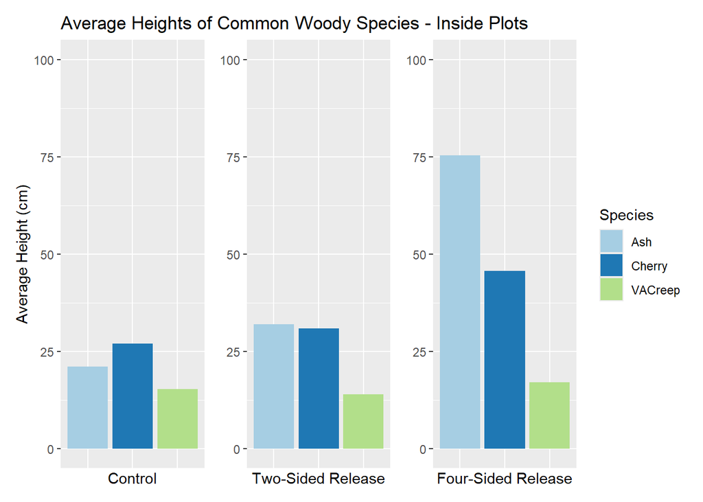

**These figures plot the average heights of species that occur both inside and outside a treatment zone for each individual treatment. The plots compare the average heights of the woody individuals inside and outside, browsed and unbrowsed.**

**In the Control plot, there were no recorded browsed individuals of Virginia Creeper.**

**In the Two-Sided Release plot, there was one recorded browsed Rosa Multiflora individual, but its height was not measured. The plot does not reflect how that individual’s average height was recorded as “NA.”**

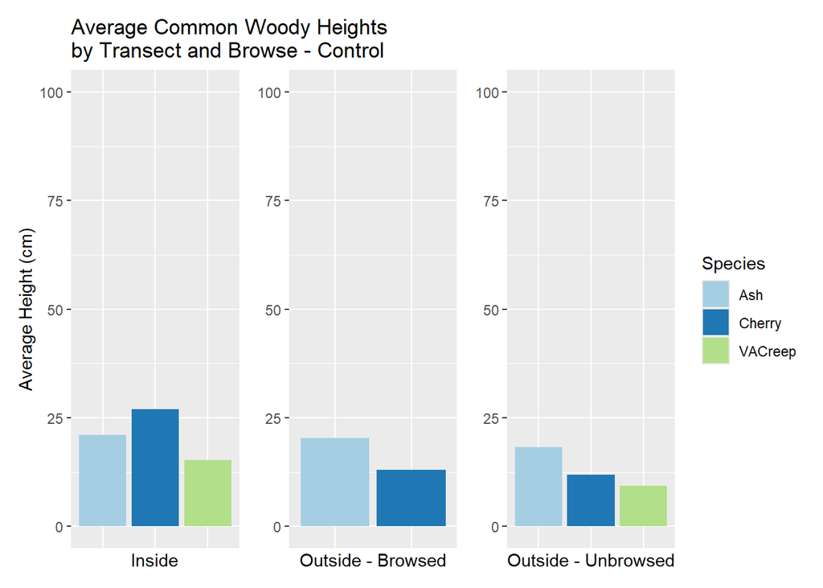

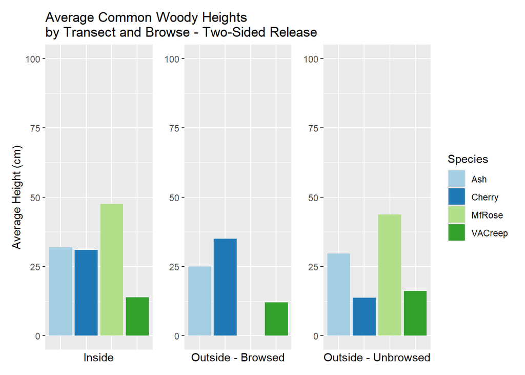

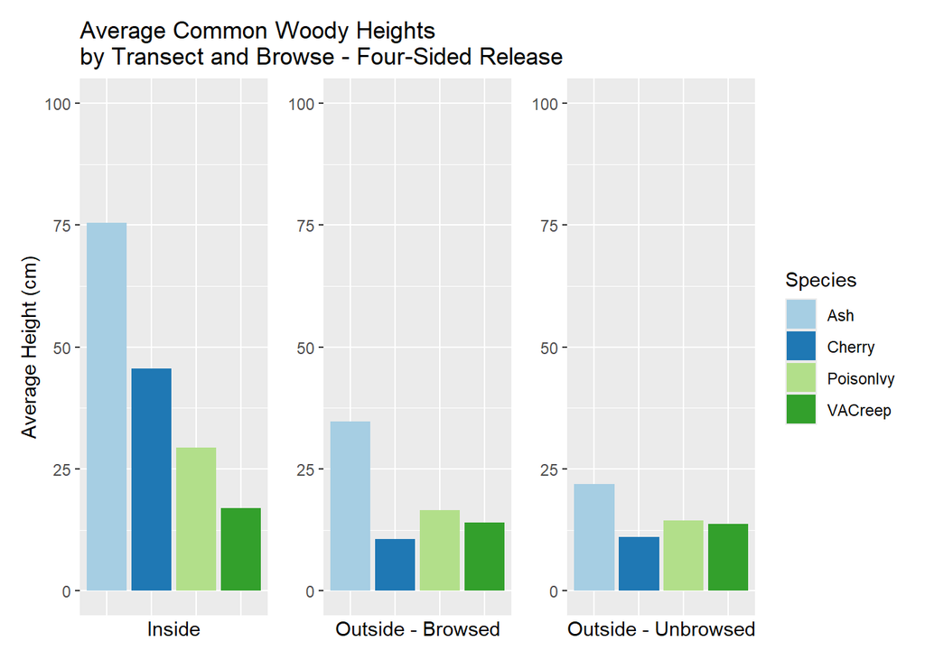

## Total Data Analysis Outputs for All Three Treatments

**The full analysis for each treatment group is as follows.**

### Control - Complete Outputs

```
## [1] "Occular Cover Averages"
## # A tibble: 6 × 6
##   Location      `Woody_%` `Grasses_%` `Forbs_%` `NVGround_%` `Other_%`
##   <chr>             <dbl>       <dbl>     <dbl>        <dbl>     <dbl>
## 1 East Inside       0.308       0.01      0.078        0.625     0.042
## 2 West Inside       0.078       0.072     0.122        0.667     0.015
## 3 East Outside      0.137       0.022     0.055        0.782     0.01
## 4 West Outside      0.112       0.002     0.065        0.725     0
## 5 Inside Total      0.192       0.041     0.1          0.646     0.029
## 6 Outside Total     0.125       0.013     0.06         0.754     0.005
## [1] "Inside: Species Richness"
##   Key Count
## 1   F    10
## 2   G     3
## 3   W    14
## 4   O     2
## [1] "Outside: Species Richness"
##   Key Count
## 1   F     8
## 2   G     3
## 3   W    14
## 4   O     1
## [1] "Inside: Count and Proportion of Invasive Species"
## # A tibble: 2 × 4
##   Key   Invasive_Count Tot_Count Prop_Invasive
##   <chr>          <int>     <int>         <dbl>
## 1 F                 11        71         0.155
## 2 W                  3       126         0.024
## [1] "Outside: Count and Proportion of Invasive Species"
## # A tibble: 2 × 4
##   Key   Invasive_Count Tot_Count Prop_Invasive
##   <chr>          <int>     <int>         <dbl>
## 1 F                  3        46         0.065
## 2 W                 13        84         0.155
## [1] "Inside: Woody Average Heights"
##     Species Average_Height
## 1       Ash           21.1
## 2    BlkGum           13.8
## 3 BlkhawVib           48.0
## 4    Cherry           27.0
```

[output cut: 12 more lines]

```
## # Groups:   Browse, Species [12]
##    Browse Species      AvgHeight Count
##     <dbl> <chr>            <dbl> <int>
##  1      0 Ash               18.3    12
##  2      0 Cherry            11.9     9
##  3      0 EnchantNight     NaN      10
##  4      0 JewelW           NaN      10
##  5      0 MfRose            22.3     3
##  6      0 Persicaria       NaN       6
##  7      0 Solidago         NaN       7
##  8      0 VACreep            9.4     9
##  9      1 Ash               20.3    20
## 10      1 Cherry            13       3
## 11      1 MfRose            30       7
## 12      1 Solidago         NaN       2
```

### Two-Sided Release - Complete Outputs

```
## [1] "Occular Cover Averages"
## # A tibble: 6 × 6
##   Location      `Woody_%` `Grasses_%` `Forbs_%` `NVGround_%` `Other_%`
##   <chr>             <dbl>       <dbl>     <dbl>        <dbl>     <dbl>
## 1 East Inside       0.298       0.057     0.22         0.382         0
## 2 West Inside       0.38        0.015     0.208        0.478         0
## 3 East Outside      0.266       0.006     0.116        0.591         0
## 4 West Outside      0.278       0.07      0.158        0.527         0
## 5 Inside Total      0.339       0.036     0.214        0.43          0
## 6 Outside Total     0.272       0.042     0.139        0.556         0
## [1] "Inside: Species Richness"
##   Key Count
## 1   F    11
## 2   G     4
## 3   W     9
## 4   O     0
## [1] "Outside: Species Richness"
##   Key Count
## 1   F     9
## 2   G     2
## 3   W     8
## 4   O     0
## [1] "Inside: Count and Proportion of Invasive Species"
## # A tibble: 3 × 4
##   Key   Invasive_Count Tot_Count Prop_Invasive
##   <chr>          <int>     <int>         <dbl>
## 1 F                 15       188         0.08
## 2 G                 27        72         0.375
## 3 W                 12       160         0.075
## [1] "Outside: Count and Proportion of Invasive Species"
## # A tibble: 3 × 4
##   Key   Invasive_Count Tot_Count Prop_Invasive
##   <chr>          <int>     <int>         <dbl>
## 1 F                 56       175         0.32
## 2 G                 60        65         0.923
## 3 W                 27       169         0.16
## [1] "Inside: Woody Average Heights"
##     Species Average_Height
## 1       Ash           31.9
## 2    Cherry           30.9
```

[output cut: 30 more lines]

```
## 10      0 Rubus          NaN       6
## 11      0 UnkForb        NaN       5
## 12      0 VACreep         16.2    65
## 13      0 WhiteAvens     NaN       5
## 14      1 Ash             25      23
## 15      1 BlkCherry       37.5     7
## 16      1 Cherry          35       2
## 17      1 JewelW         NaN      16
## 18      1 MfRose         NaN       1
## 19      1 Nightshade     NaN       3
## 20      1 Persicaria     NaN       1
## 21      1 Rubus           32       5
## 22      1 UnkForb        NaN       4
## 23      1 VACreep         12       6
## 24      1 WhiteAvens     NaN       1
```

### Four-Sided Release - Complete Outputs

```
## [1] "Occular Cover Averages"
## # A tibble: 6 × 6
##   Location      `Woody_%` `Grasses_%` `Forbs_%` `NVGround_%` `Other_%`
##   <chr>             <dbl>       <dbl>     <dbl>        <dbl>     <dbl>
## 1 East Inside       0.31        0.36      0.17         0.265     0
## 2 West Inside       0.428       0.182     0.032        0.348     0
## 3 East Outside      0.215       0.288     0.098        0.415     0.015
## 4 West Outside      0.195       0.282     0.085        0.43      0
## 5 Inside Total      0.369       0.271     0.101        0.306     0
## 6 Outside Total     0.205       0.285     0.091        0.422     0.007
## [1] "Inside: Species Richness"
##   Key Count
## 1   F     8
## 2   G     3
## 3   W    13
## 4   O     0
## [1] "Outside: Species Richness"
##   Key Count
## 1   F     8
## 2   G     3
## 3   W    15
## 4   O     1
## [1] "Inside: Count and Proportion of Invasive Species"
## # A tibble: 2 × 4
##   Key   Invasive_Count Tot_Count Prop_Invasive
##   <chr>          <int>     <int>         <dbl>
## 1 G                581       586         0.991
## 2 W                  5       161         0.031
## [1] "Outside: Count and Proportion of Invasive Species"
## # A tibble: 3 × 4
##   Key   Invasive_Count Tot_Count Prop_Invasive
##   <chr>          <int>     <int>         <dbl>
## 1 F                  2       128         0.016
## 2 G                429       459         0.935
## 3 W                 17       136         0.125
## [1] "Inside: Woody Average Heights"
##     Species Average_Height
## 1       Ash           75.4
## 2    Cherry           45.6
## 3 PoisonIvy           29.4
```

[output cut: 29 more lines]

```
## 10      0 PoisonIvy         14.5    14
## 11      0 UnkForb          NaN      11
## 12      0 VACreep           13.7    22
## 13      0 Violet           NaN       7
## 14      1 Ash               34.8    31
## 15      1 Cherry            10.7     3
## 16      1 CinqSpp          NaN       1
## 17      1 EnchantNight     NaN       1
## 18      1 JewelW           NaN      25
## 19      1 MfRose            74.5     2
## 20      1 Nightshade       NaN       1
## 21      1 Persicaria       NaN       2
## 22      1 PoisonIvy         16.5     6
## 23      1 VACreep           14      14
## 24      1 Violet           NaN       1
```